# Dimensionality Reduction Project

### Subject:

Use the tools and methodology seen to reduce the dimensionality of your data to be able to focus on the most important features. Choose the best approach to reduce the dimensionality and to project the data. Explain the model and why it works best for this problem/dataset. Use Python with matplotlib and/or KNIME to plot the dataset and the knowledge extracted from it. Explain the knowledge you extracted.

The same dataset can be used for both projects.

### I - Prepare the dataset

```python
import pandas as pd
import matplotlib.pyplot as plt
from sklearn import *
import numpy as np
import seaborn as sns
from sklearn.preprocessing import StandardScaler
```

For this project we choose to analyze the white wine quality dataset.

```python
data = pd.read_csv("winequality-white.csv",sep=";")

data.info()
data.head()
```

```
<class 'pandas.core.frame.DataFrame'>
RangeIndex: 4898 entries, 0 to 4897
Data columns (total 12 columns):
 #   Column                Non-Null Count  Dtype
---  ------                --------------  -----
 0   fixed acidity         4898 non-null   float64
 1   volatile acidity      4898 non-null   float64
 2   citric acid           4898 non-null   float64
 3   residual sugar        4898 non-null   float64
 4   chlorides             4898 non-null   float64
 5   free sulfur dioxide   4898 non-null   float64
 6   total sulfur dioxide  4898 non-null   float64
 7   density               4898 non-null   float64
 8   pH                    4898 non-null   float64
 9   sulphates             4898 non-null   float64
 10  alcohol               4898 non-null   float64
 11  quality               4898 non-null   int64
dtypes: float64(11), int64(1)
memory usage: 459.3 KB
```

|  | fixed acidity | volatile acidity | citric acid | residual sugar | chlorides | free sulfur dioxide | total sulfur dioxide | density | pH | sulphates | alcohol | quality |
| --- | --- | --- | --- | --- | --- | --- | --- | --- | --- | --- | --- | --- |
| 0 | 7.0 | 0.27 | 0.36 | 20.7 | 0.045 | 45.0 | 170.0 | 1.0010 | 3.00 | 0.45 | 8.8 | 6 |
| 1 | 6.3 | 0.30 | 0.34 | 1.6 | 0.049 | 14.0 | 132.0 | 0.9940 | 3.30 | 0.49 | 9.5 | 6 |
| 2 | 8.1 | 0.28 | 0.40 | 6.9 | 0.050 | 30.0 | 97.0 | 0.9951 | 3.26 | 0.44 | 10.1 | 6 |
| 3 | 7.2 | 0.23 | 0.32 | 8.5 | 0.058 | 47.0 | 186.0 | 0.9956 | 3.19 | 0.40 | 9.9 | 6 |
| 4 | 7.2 | 0.23 | 0.32 | 8.5 | 0.058 | 47.0 | 186.0 | 0.9956 | 3.19 | 0.40 | 9.9 | 6 |

We can see here that our dataset is already **clean** because there are not any **null values**.  
Furthermore all our features have the correct **type**.  
Now we can use the describe() method to check the range of values for the variables.

```python
data.describe()
```

|  | fixed acidity | volatile acidity | citric acid | residual sugar | chlorides | free sulfur dioxide | total sulfur dioxide | density | pH | sulphates | alcohol | quality |
| --- | --- | --- | --- | --- | --- | --- | --- | --- | --- | --- | --- | --- |
| count | 4898.000000 | 4898.000000 | 4898.000000 | 4898.000000 | 4898.000000 | 4898.000000 | 4898.000000 | 4898.000000 | 4898.000000 | 4898.000000 | 4898.000000 | 4898.000000 |
| mean | 6.854788 | 0.278241 | 0.334192 | 6.391415 | 0.045772 | 35.308085 | 138.360657 | 0.994027 | 3.188267 | 0.489847 | 10.514267 | 5.877909 |
| std | 0.843868 | 0.100795 | 0.121020 | 5.072058 | 0.021848 | 17.007137 | 42.498065 | 0.002991 | 0.151001 | 0.114126 | 1.230621 | 0.885639 |
| min | 3.800000 | 0.080000 | 0.000000 | 0.600000 | 0.009000 | 2.000000 | 9.000000 | 0.987110 | 2.720000 | 0.220000 | 8.000000 | 3.000000 |
| 25% | 6.300000 | 0.210000 | 0.270000 | 1.700000 | 0.036000 | 23.000000 | 108.000000 | 0.991723 | 3.090000 | 0.410000 | 9.500000 | 5.000000 |
| 50% | 6.800000 | 0.260000 | 0.320000 | 5.200000 | 0.043000 | 34.000000 | 134.000000 | 0.993740 | 3.180000 | 0.470000 | 10.400000 | 6.000000 |
| 75% | 7.300000 | 0.320000 | 0.390000 | 9.900000 | 0.050000 | 46.000000 | 167.000000 | 0.996100 | 3.280000 | 0.550000 | 11.400000 | 6.000000 |
| max | 14.200000 | 1.100000 | 1.660000 | 65.800000 | 0.346000 | 289.000000 | 440.000000 | 1.038980 | 3.820000 | 1.080000 | 14.200000 | 9.000000 |

The **first step** before doing any **dimensionality reduce method** is to have an idea about the **relation of features**. Some columns may be **strongly related** and others can be **independant**. Using our dataset, we can compute a **correlation matrix** to observe our 12 features and have a first idea.

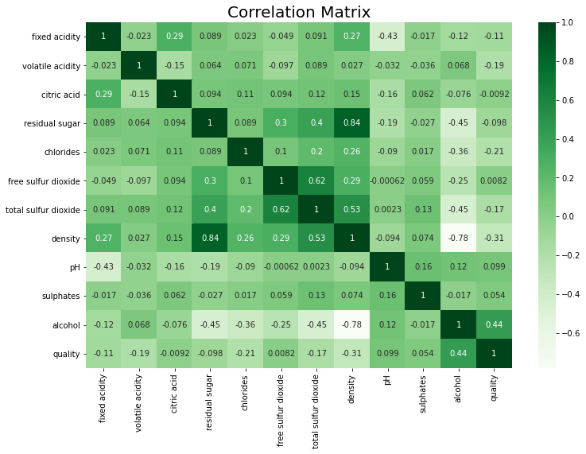

```python
plt.figure(figsize=(12,8))
ax = sns.heatmap(data.corr(), cmap='Greens', annot=True)
plt.title("Correlation Matrix", fontsize=20)
plt.show()
```

As we saw with the **describe()** method, some features have some disparities. For example the **minimum and maximum** value for the **"fixed acidity"** feature are respectively **3.80 and 14.20**, while the **miminimum and maximum** value for the **"volatile acidity"** feature are respectively **0.08 and 1.10**. To address this we need to **standardize** the dataset.

```python
data["quality label"] = ""
for i in range(len(data)):
    if 0 <= data.iloc[i]["quality"] <= 4:
        data.at[i,"quality label"] = "Bad"
    elif 5 <= data.iloc[i]["quality"] <= 6:
        data.at[i,"quality label"] = "Medium"
    elif data.iloc[i]["quality"] >= 7:
        data.at[i,"quality label"] = "Excellent"
```

```python
data.head()
```

|  | fixed acidity | volatile acidity | citric acid | residual sugar | chlorides | free sulfur dioxide | total sulfur dioxide | density | pH | sulphates | alcohol | quality | quality label |
| --- | --- | --- | --- | --- | --- | --- | --- | --- | --- | --- | --- | --- | --- |
| 0 | 7.0 | 0.27 | 0.36 | 20.7 | 0.045 | 45.0 | 170.0 | 1.0010 | 3.00 | 0.45 | 8.8 | 6 | Medium |
| 1 | 6.3 | 0.30 | 0.34 | 1.6 | 0.049 | 14.0 | 132.0 | 0.9940 | 3.30 | 0.49 | 9.5 | 6 | Medium |
| 2 | 8.1 | 0.28 | 0.40 | 6.9 | 0.050 | 30.0 | 97.0 | 0.9951 | 3.26 | 0.44 | 10.1 | 6 | Medium |
| 3 | 7.2 | 0.23 | 0.32 | 8.5 | 0.058 | 47.0 | 186.0 | 0.9956 | 3.19 | 0.40 | 9.9 | 6 | Medium |
| 4 | 7.2 | 0.23 | 0.32 | 8.5 | 0.058 | 47.0 | 186.0 | 0.9956 | 3.19 | 0.40 | 9.9 | 6 | Medium |

```python
columns = ['fixed acidity', 'volatile acidity', 'citric acid', 'residual sugar', 'chlorides', 'free sulfur dioxide', 'total sulfur dioxide', 'density', 'pH', 'sulphates', 'alcohol']
x = data[columns]
label = data['quality label']
```

```
(-5.0, 20.0)
```

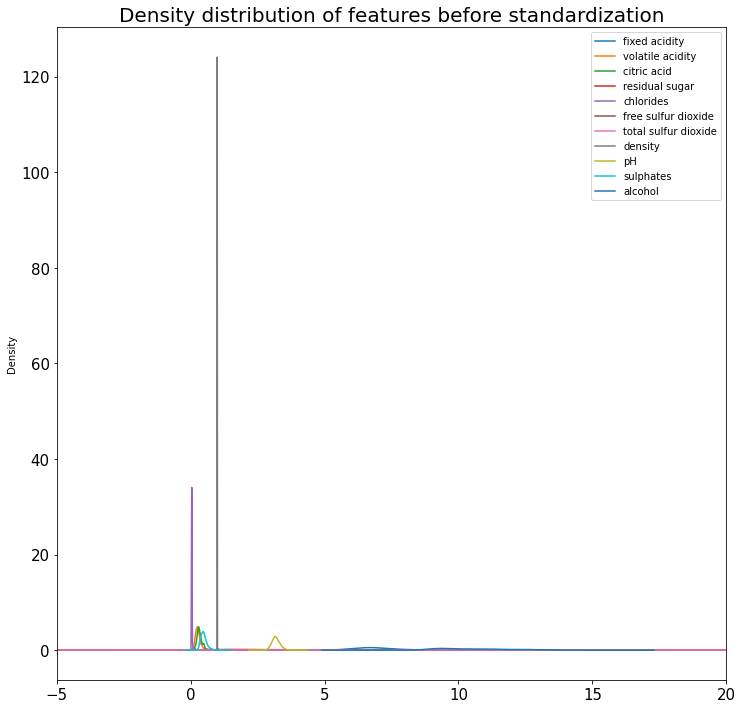

```python
x.plot(kind='density',fontsize=15,sharex=True,figsize=(12,12),layout=(10,1))
plt.title("Density distribution of features before standardization", fontsize=20)
plt.xlim(-5,20)
```

```python
# Standardize the data
scaler = StandardScaler()
data_scaled = scaler.fit_transform(x)
data_scaled
```

```
array([[ 1.72096961e-01, -8.17699008e-02,  2.13280202e-01, ...,
        -1.24692128e+00, -3.49184257e-01, -1.39315246e+00],
       [-6.57501128e-01,  2.15895632e-01,  4.80011213e-02, ...,
         7.40028640e-01,  1.34184656e-03, -8.24275678e-01],
       [ 1.47575110e+00,  1.74519434e-02,  5.43838363e-01, ...,
         4.75101984e-01, -4.36815783e-01, -3.36667007e-01],
       ...,
       [-4.20473102e-01, -3.79435433e-01, -1.19159198e+00, ...,
        -1.31315295e+00, -2.61552731e-01, -9.05543789e-01],
       [-1.60561323e+00,  1.16673788e-01, -2.82557040e-01, ...,
         1.00495530e+00, -9.62604939e-01,  1.85757201e+00],
       [-1.01304317e+00, -6.77100966e-01,  3.78559282e-01, ...,
         4.75101984e-01, -1.48839409e+00,  1.04489089e+00]])
```

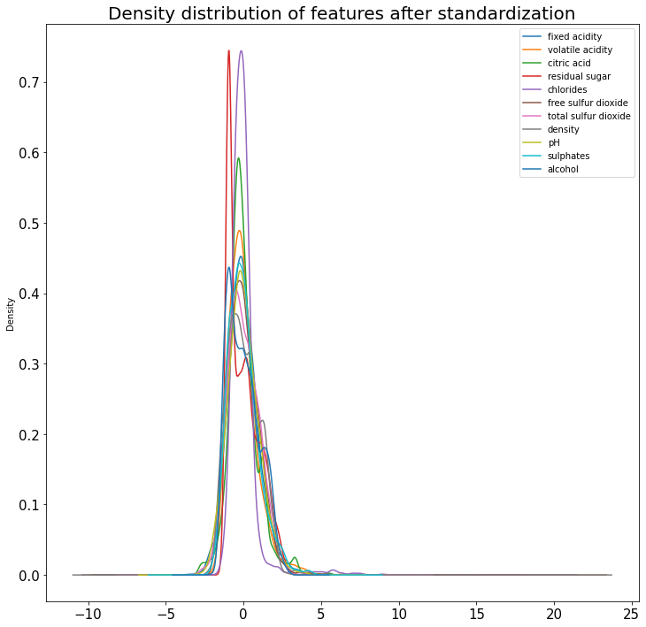

```python
X = pd.DataFrame(data_scaled,columns=columns)
X.plot(kind='density',fontsize=15,sharex=True,figsize=(12,12),layout=(10,1))
plt.title("Density distribution of features after standardization", fontsize=20)
```

We can see that all the distributions are now **centered** around the **0 value** and have a **similar spread**. The variation in the data is still preserved (you can see that the shape of the density plot lines remains similar to the original plot for each variable).

Now that we have removed the bias caused by different scales we can proceed to the dimension reduction methods.

### II - Dimension reduction

#### II.1 - PCA

```python
from sklearn.decomposition import PCA

# we have 12 variables, so the maximum number of principal components has to be 12
nb_components = 11
pca = PCA(n_components = nb_components)
pca.fit(data_scaled)
data_pca = pca.transform(data_scaled)
```

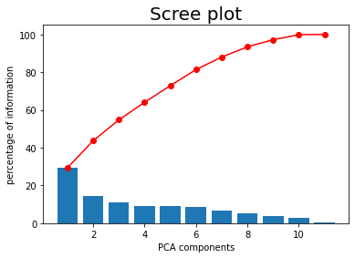

```python
def display_scree_plot(pca):
    scree = pca.explained_variance_ratio_*100
    plt.bar(np.arange(len(scree))+1, scree)
    plt.plot(np.arange(len(scree))+1, scree.cumsum(),c="red",marker='o')
    plt.xlabel("PCA components",fontsize=10)
    plt.ylabel("percentage of information",fontsize=10)
    plt.title("Scree plot",fontsize=20)
    plt.show(block=False)

display_scree_plot(pca)
```

According to the plot above, we need minimum **7 components** to get **87%** of information. We can have more precision about those value with the explained variance cumulative sum method.

```python
pca.explained_variance_ratio_.cumsum()
```

```
array([0.29293217, 0.4361358 , 0.54719683, 0.63978977, 0.72827474,
       0.81361487, 0.87966924, 0.93415637, 0.9718058 , 0.99812281,
       1.        ])
```

```python
data_pca = pd.DataFrame(data_pca)
```

```python
data_pca['target'] = label
data_pca.columns = ['PC1','PC2','PC3','PC4','PC5','PC6','PC7','PC8','PC9','PC10','PC11','target']
data_pca.head()
```

|  | PC1 | PC2 | PC3 | PC4 | PC5 | PC6 | PC7 | PC8 | PC9 | PC10 | PC11 | target |
| --- | --- | --- | --- | --- | --- | --- | --- | --- | --- | --- | --- | --- |
| 0 | 3.676944 | -0.545233 | -0.930422 | -1.135374 | -0.292855 | -0.891620 | 0.204664 | -1.025184 | 0.150609 | -0.075905 | 0.042190 | Medium |
| 1 | -0.644588 | 0.430770 | -0.356331 | 0.999117 | -0.714078 | -0.483738 | 0.436998 | 0.584930 | -1.063550 | -0.253919 | 0.127904 | Medium |
| 2 | 0.155291 | -1.189800 | -0.017532 | 0.270219 | -0.367706 | -0.500682 | 0.554319 | 0.974902 | 0.549654 | 0.855570 | -0.184295 | Medium |
| 3 | 1.455374 | 0.099680 | -0.001956 | -0.423022 | -0.469981 | 0.769261 | -0.197702 | 0.601653 | 0.293244 | -0.403700 | -0.045274 | Medium |
| 4 | 1.455374 | 0.099680 | -0.001956 | -0.423022 | -0.469981 | 0.769261 | -0.197702 | 0.601653 | 0.293244 | -0.403700 | -0.045274 | Medium |

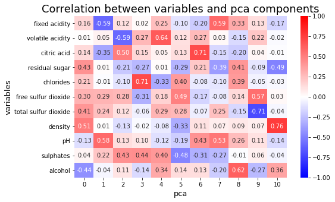

```python
plt.figure(figsize=(8,5))
colnames = columns
hm = sns.heatmap(pca.components_.T, cbar=True, annot=True, cmap='bwr', fmt=".2f",
annot_kws={"size":10}, yticklabels=colnames, vmax=1, vmin=-1, center=0)
plt.xlabel("pca",fontsize=13)
plt.ylabel("variables",fontsize=13)
plt.title("Correlation between variables and pca components",fontsize=18)
```

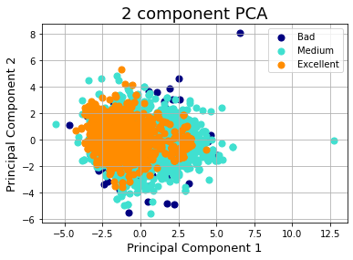

```python
fig = plt.figure()
ax = fig.add_subplot(1,1,1)
ax.set_xlabel("Principal Component 1",fontsize=13)
ax.set_ylabel("Principal Component 2",fontsize=13)
ax.set_title("2 component PCA",fontsize=18)
targets = ["Bad", "Medium", "Excellent"]
colors = ['navy', 'turquoise', 'darkorange']
for target, color in zip(targets,colors):
     indicesToKeep = data_pca["target"] == target
     ax.scatter(data_pca.loc[indicesToKeep, "PC1"]
     , data_pca.loc[indicesToKeep, "PC2"]
     , c = color
     , s = 50)
ax.legend(targets)
ax.grid()
```

```python
#pd.DataFrame(pca.components_)
pd.DataFrame(data_pca).head()
```

|  | PC1 | PC2 | PC3 | PC4 | PC5 | PC6 | PC7 | PC8 | PC9 | PC10 | PC11 | target |
| --- | --- | --- | --- | --- | --- | --- | --- | --- | --- | --- | --- | --- |
| 0 | 3.676944 | -0.545233 | -0.930422 | -1.135374 | -0.292855 | -0.891620 | 0.204664 | -1.025184 | 0.150609 | -0.075905 | 0.042190 | Medium |
| 1 | -0.644588 | 0.430770 | -0.356331 | 0.999117 | -0.714078 | -0.483738 | 0.436998 | 0.584930 | -1.063550 | -0.253919 | 0.127904 | Medium |
| 2 | 0.155291 | -1.189800 | -0.017532 | 0.270219 | -0.367706 | -0.500682 | 0.554319 | 0.974902 | 0.549654 | 0.855570 | -0.184295 | Medium |
| 3 | 1.455374 | 0.099680 | -0.001956 | -0.423022 | -0.469981 | 0.769261 | -0.197702 | 0.601653 | 0.293244 | -0.403700 | -0.045274 | Medium |
| 4 | 1.455374 | 0.099680 | -0.001956 | -0.423022 | -0.469981 | 0.769261 | -0.197702 | 0.601653 | 0.293244 | -0.403700 | -0.045274 | Medium |

**PCA** doesn't seem to show us a good visualization with a clear repartition Let's try **LDA**:

#### II.2 - LDA

```python
from sklearn.discriminant_analysis import LinearDiscriminantAnalysis as LDA

#x = data.loc[:,'fixed acidity':'alcohol']
#y = data["quality"]
lda_2c = LDA(n_components=2)
data_lda_2c = lda_2c.fit_transform(x,label)
print(data_lda_2c.shape)
```

```
(4898, 2)
```

```python
target_names = np.unique(label)
print(target_names)
```

```
['Bad' 'Excellent' 'Medium']
```

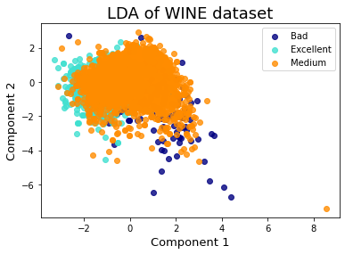

```python
fig = plt.figure()
ax = fig.add_subplot(1,1,1)
ax.set_xlabel("Component 1",fontsize=13)
ax.set_ylabel("Component 2",fontsize=13)
ax.set_title("LDA of WINE dataset",fontsize=18)
colors = ['navy', 'turquoise', 'darkorange']
for color, i, target_name in zip(colors, target_names, target_names):
     plt.scatter(data_lda_2c[label == i, 0], data_lda_2c[label == i, 1], alpha=.8, color=color,
     label=target_name)
plt.legend(loc="best", shadow=False, scatterpoints=1)
```

```python
df = data_pca[["PC1","PC2","PC3","PC4","PC5","PC6","PC7","target"]]
```

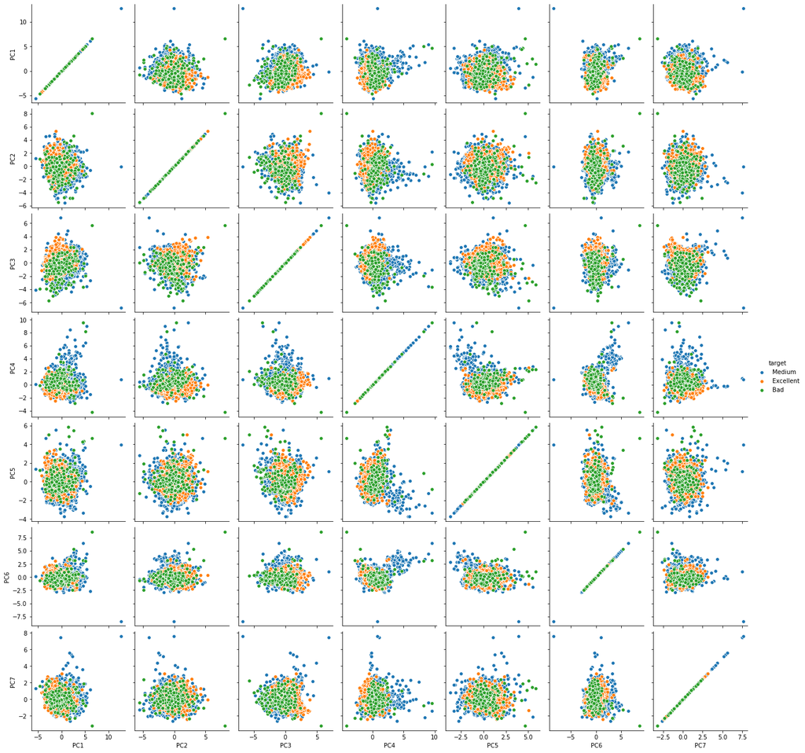

```python
sns.pairplot(df, height=2.5, diag_kind=None, hue="target");
```

Here we can clearly see that whatever the components, there is not a good repartition.

If PCA and LDA don't work, it means that our features either have non-linear relationships or no relationship at all. That could possibily mean that Wine Quality column is not correlated to Wine attributes in linear manner.

**LDA** and **PCA** are components/Factors based dimensionality reduction method. Let's try **Projection based methods** such as **t-SNE** or **Isomap** to check if we can have a good visualition with those methods.

```python
from sklearn.manifold import TSNE



tsne = TSNE(n_components=2, verbose=1, perplexity=40, n_iter=300)
x_reduced = tsne.fit_transform(x)
```

```
[t-SNE] Computing 121 nearest neighbors...
[t-SNE] Indexed 4898 samples in 0.024s...
[t-SNE] Computed neighbors for 4898 samples in 0.192s...
[t-SNE] Computed conditional probabilities for sample 1000 / 4898
[t-SNE] Computed conditional probabilities for sample 2000 / 4898
[t-SNE] Computed conditional probabilities for sample 3000 / 4898
[t-SNE] Computed conditional probabilities for sample 4000 / 4898
[t-SNE] Computed conditional probabilities for sample 4898 / 4898
[t-SNE] Mean sigma: 3.405004
[t-SNE] KL divergence after 250 iterations with early exaggeration: 67.034683
[t-SNE] KL divergence after 300 iterations: 1.544268
```

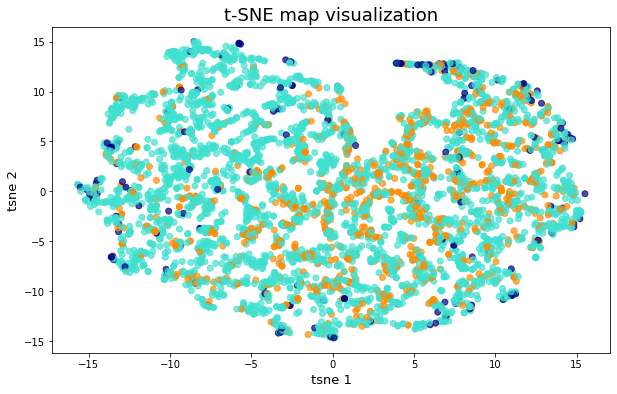

```python
x = x_reduced[:,0]
y = x_reduced[:,1]

colors = []

for i in label:
    if i == "Bad":
        colors.append("navy")
    elif i == "Medium":
        colors.append("turquoise")
    else:
        colors.append("darkorange")

plt.figure(figsize=(10,6))
plt.scatter(x,y,c=colors, alpha=0.7)
plt.xlabel("tsne 1",fontsize=13)
plt.ylabel("tsne 2",fontsize=13)
plt.title("t-SNE map visualization",fontsize=18)
```

**t-SNE** is one of the **projection based method** mentioned above. It is a **nonlinear method** for representing a set of points. In our case, we cannot interpret this projection because there is not a clear repartition between each class("Excellent", "Medium", "Bad").  
Let's try Isomap method:

```python
# Library
from sklearn.manifold import Isomap



# Create instance
iso = Isomap(n_components=2)
```

```python
iso.fit(data_scaled)
iso_projected = iso.transform(data_scaled)
```

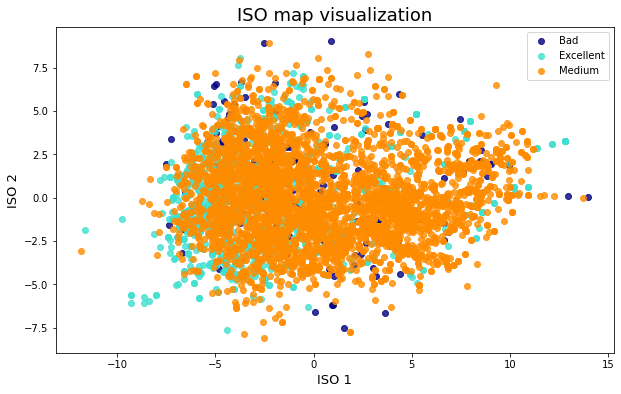

```python
x = iso_projected[:,0]
y = iso_projected[:,1]
#qual = label



plt.figure(figsize=(10,6))
plt.xlabel("ISO 1",fontsize=13)
plt.ylabel("ISO 2",fontsize=13)
plt.title("ISO map visualization",fontsize=18)
colors = ['navy', 'turquoise', 'darkorange']
for color, i, target_name in zip(colors, target_names, target_names):
     plt.scatter(iso_projected[label == i, 0], iso_projected[label == i, 1], alpha=.8, color=color,
     label=target_name)
plt.legend(loc="best", shadow=False, scatterpoints=1)
```

**Medium** and **Excellent** wines are more centerd in this graph but it's not really the case of **Bad** wines which are more around **Medium** and **Excellent** wines.

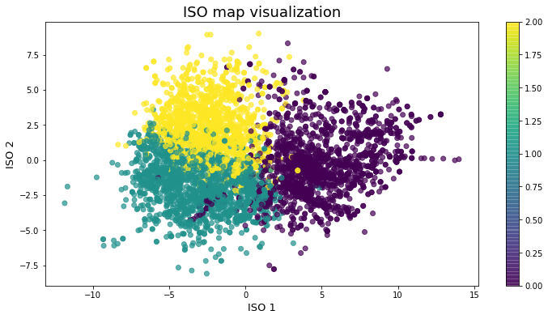

```python
from sklearn.cluster import KMeans
kmeans = KMeans(n_clusters=3, max_iter=30, init="k-means++", random_state=10)



# Fitting
kmeans.fit(data_scaled)



# output
cluster = kmeans.labels_



# visualization, quality
x = iso_projected[:,0]
y = iso_projected[:,1]



plt.figure(figsize=(12,6))
plt.scatter(x,y,c=cluster, alpha=0.7)
plt.xlabel("ISO 1",fontsize=13)
plt.ylabel("ISO 2",fontsize=13)
plt.title("ISO map visualization",fontsize=18)
plt.colorbar()
```

During this project we tried to reduce the dimensionality of the wine quality dataset to be able to focus on the most important features. So we first tried **component/factor based dimensionality reduction** method such as **PCA** and **LDA**. As expected those methods reduced the dimension of our dataset while keeping most of the information from the original dataset, however they were not able to propose a clear repartition of the data. That could possibly mean that our features either have **non-linear relationships** or **no relationship at all**. So we decided to use **projection based method** such as **t-sne** and **isomap**. Unfortunately, the results were not clear either. The reason is that the feature "quality" is given by an **oenologist**, it means that the relation between the feature "quality" and the components of the wine is not that strong. The quality of a wine is a feature that is a **little bit biased**, indeed an excellent wine can have a totally different composition than another excellent wine. One solution could be to use **clustering** to improve the repartition of the data in order to facilitate the **prediction step**.